# Final Assessment

- Show All Code
- Hide All Code
- View Source

Author

Marie-Anna Sedlinska

Published

April 24, 2024

```r
# Load libraries
library(here)
library(tidyverse)
library(lubridate)
library(unibeCols)
library(medicaldata)
library(dplyr)
library(usethis)
```

## Introduction

This aim of this report is to visualize the proportion of positive and negative COVID-19 tests by gender and calculate whether there was a significant difference between the proportion of positive and negative COVID-19 between the genders. The covid_testing dataset from the medicaldata package in R will be used for this analysis.

## Data

The data from the medicaldata package in R were used. Information about the dataset can be accessed here: https://cran.r-project.org/web/packages/medicaldata/medicaldata.pdf

```r
# Read data and assigning them to an object
# Data comes from the medicaldata package in R

data_covid <- covid_testing
```

```r
# Process data
sorted_covid <- data_covid %>%
  arrange(pan_day)

# Summary table with counts of positive and negative cases for each gender
summary_table <- sorted_covid %>%
  group_by(gender, result) %>%
  summarise(count = n())
# Calculating proportions
summary_table <- summary_table %>%
  group_by(gender) %>%
  mutate(proportion = count / sum(count))
```

```r
# Data Analysis
# Differences in the number of positive and negative COVID-19 test results between genders.
# Applying chi-squared test

cont_table <- table(sorted_covid$gender, sorted_covid$result)

# Perform chi-square test of independence
chi_sq_test <- chisq.test(cont_table)
```

### Numbers of positive, negative and invalid Covid-19 test results per Gender

```r
# Print contingency table
print(cont_table)
```

```
         invalid negative positive
  female     146     7237      449
  male       155     7121      416
```

### Chi-squared test results

```r
# Print chi-square test result
print(chi_sq_test)
```

```
    Pearson's Chi-squared test

data:  cont_table
X-squared = 1.2028, df = 2, p-value = 0.5481
```

## Analysis Conclusion

The results of the chi-squared test showed that there is no significant difference in the COVID-19 test results between the genders.

### Figure 1: Proportions of Positive and Negative Covid-19 Tests by Gender

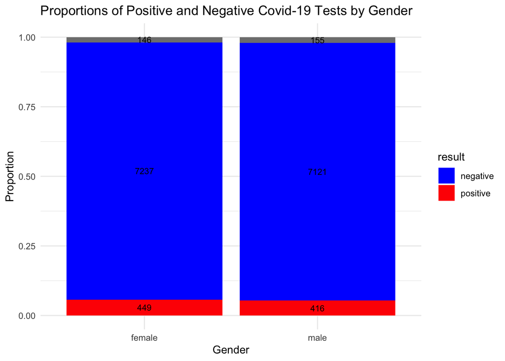

## Conclusion

The aim of this report was to visualise the proportion of positive and negative COVID-19 tests by gender. By visual inspection, we can see that the proportion of positive and negative tests does not seem to differ meaningfully between genders. Applying the chi-squared test, there was no significant difference between the numbers of positive and negavtive COVID-19 tests by gender.